# Variant calling and validation

In this vignette, we demonstrate how to call true mitochondrial somatice variants from single-cell RNA-seq data **from single individuals**, and we further justify our filtering strategy using reference data. In particular, we here make use of a blacklist created in the vignette Variant calling and blacklist creation (using cohort data).

## Before you begin

The functions documented in this vignette use count tables of variants in the mitochondrial genome as input. Such tables are created from bam files using the function `baseCountsFromBamList`.

## Example Ludwig et al., Figure 5

The function `mutationCallsFromBlacklist` performs coverage-based filtering and then removes blacklisted variants. Some notes about its parameters:

- `min.af` is the minimal heteroplasmy (allele frequency) for a site to be considered mutant in a single cell. Depending on its value and the dataset, you will sometimes include variants that are present in all cells, but at a low heteroplasmy.
- `universal.var.cells` can be used to remove such variants, since it removes all variants classified as mutant in at least this number of cells (here, 50% of cells)
- `min.num.samples` specifies the minimum number of mutant cells required for a variant to be kept.

As in the case of cohort mutation calling, the choice of these parameters is quite critical. Please see the funal part of the Variant calling and blacklist creation (using cohort data) vignette for instructions how to set the parameters and/or perform sensibility checks on the results.

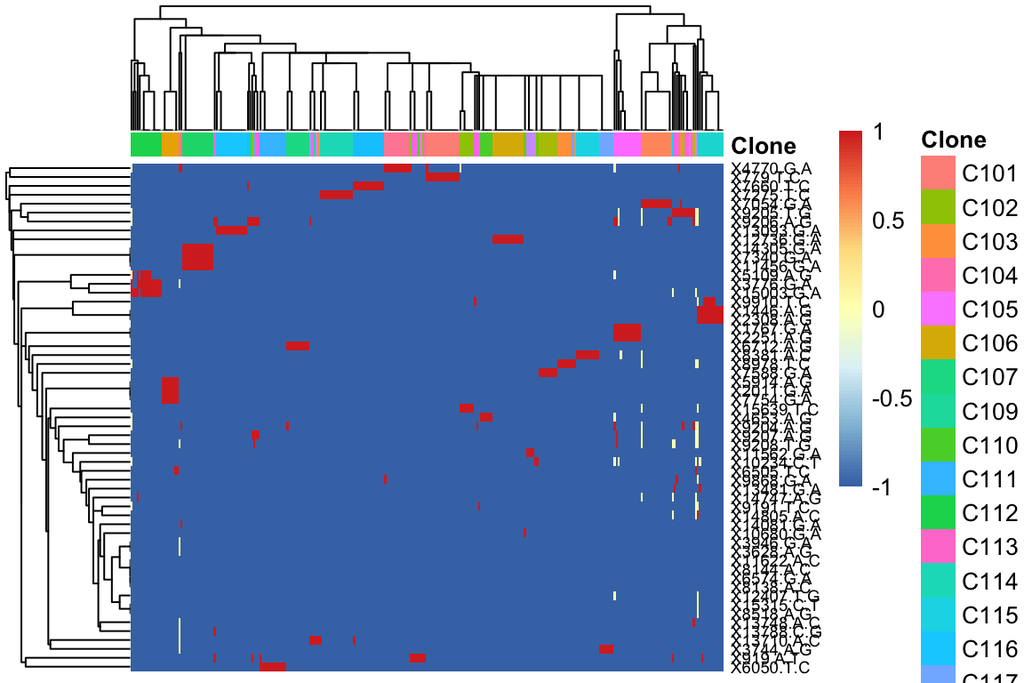

```r
library(mitoClone)
library(pheatmap)

LudwigFig5.Counts <- readRDS(url("http://steinmetzlab.embl.de/mutaseq/fig5_mc_out.RDS"))

LudwigFig5 <- mutationCallsFromBlacklist(LudwigFig5.Counts,min.af=0.05, min.num.samples=5, universal.var.cells = 0.5 * length(LudwigFig5.Counts), binarize = 0.1)

LudwigFig5.Meta <- data.frame(row.names = rownames(LudwigFig5@N), Clone = gsub("_.*","",gsub("Donor1_","",rownames(LudwigFig5@N))))

clustered <- quick_cluster(LudwigFig5, binarize = T, drop_empty = T, clustering.method = "ward.D2", annotation_col = LudwigFig5.Meta,show_colnames=F,fontsize_row = 7)
```

## Example Ludwig et al., Figure 7

For this figure, we first recapitulate the analysis by Ludwig et al., who performed unsupervised clustering using a set of variants identified by DNA sequencing.

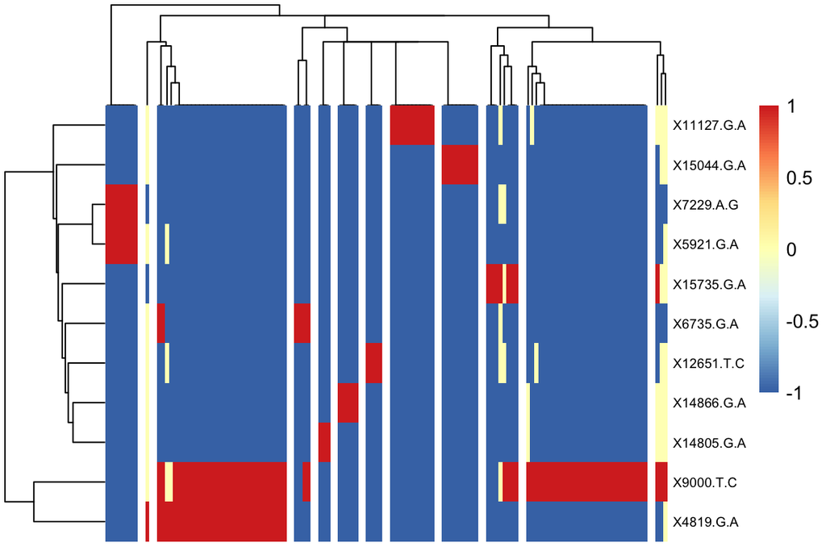

```r
## this is the Fig7 A/B data it is only the single cells from the Tumor samples (see bottom arrow of Fig7A) - It looks very messay and the healthy comparison is bulk sequencing (let me know if you think I should follow up)
LudwigFig7.Counts <- readRDS(url("http://steinmetzlab.embl.de/mutaseq/fig7_nucleotide_counts_per_position.RDS"))


supervised.variants <- c("9000 T>C","4819 G>A","11127 G>A","7229 A>G","5921 G>A","15735 G>A","15044 G>A","14866 G>A","6735 G>A","12651 T>C","14805 G>A")
shifted.pos <- as.integer(gsub(" .+","",supervised.variants)) - 1
basechange <- gsub("\\d+ ","",supervised.variants)
supervised.variants.shifted <- paste(shifted.pos, basechange)
hand.selected <- pullcounts.vars(LudwigFig7.Counts, supervised.variants, shift=-1)
hand.selected <- mutationCallsFromMatrix(t(hand.selected$M), t(hand.selected$N), cluster = rep(T, length(supervised.variants)))

clustered.hand <- quick_cluster(hand.selected, binarize = T, drop_empty = T, clustering.method = "ward.D2",fontsize_row = 7, show_colnames=F, cutree_cols = 12, cluster_distance_col = "manhattan")
```

```r
orig.anno <- data.frame(row.names = names(cutree(clustered.hand$tree_col, k=12)), Clone = as.factor(cutree(clustered.hand$tree_col, k=12)))
```

Then, we call mitochondrial variants de novo and cluster using the `muta_cluster` function, as described in more detail in the Computation of clonal hierarchies and clustering of mutations vignette.

Of note, in this dataset there is quite a large number of variants present in all cells but at low heteroplasmy, justifying the use of a different `universal.var.cells` parameter.

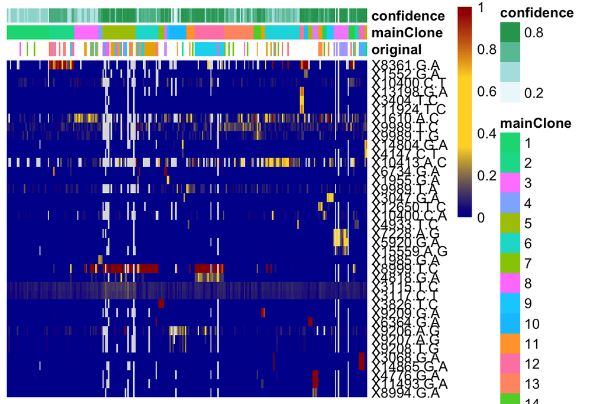

```r
LudwigFig7 <- mutationCallsFromBlacklist(LudwigFig7.Counts,min.af=0.1, min.num.samples=3, universal.var.cells = 0.25 * length(LudwigFig7.Counts), binarize = 0.1)
LudwigFig7 <- muta_cluster(LudwigFig7, cores=10,tempfolder = paste0(getwd(),"/LudwigFig7"))

LudwigFig7@metadata$original <- factor(NA, levels = unique(orig.anno$Clone))
LudwigFig7@metadata[rownames(orig.anno), "original"] <- orig.anno$Clone

LudwigFig7 <- clusterMetaclones(LudwigFig7, plot = F)

plotClones(LudwigFig7)
```